# STA101 Discussion 1

Shitong Wei

4/7/2018

First set the working directory to the directory where the data file is.

```r
setwd("~/Desktop/Spring Quarter 2018/STA101")
```

Then load the data into R.

```r
data <- read.csv("patients101.csv",header=T)
```

where *header = T* is a default option, and proper for this data set. Try *header = F* to see what happens.

Here we need package *ggplot2*. If a package is not installed on the computer, we need to install it first with *install.packages(‘package name’)*. Installation is only needed for the first time on a computer. Packages need to be imported before using.

```r
library('ggplot2')
```

## Problem 1

### a

(4.1.1 in R Handout - Summary Statistics and Plots)

Create a histogram in standard R.

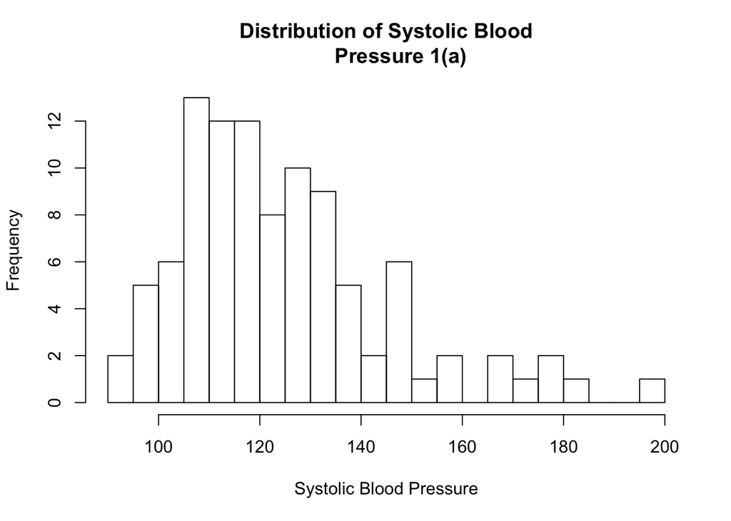

```r
hist(data$sysBP,xlab = "Systolic Blood Pressure",main="Distribution of Systolic Blood
     Pressure 1(a)",breaks=20)
```

Create a histogram with ggplot2.

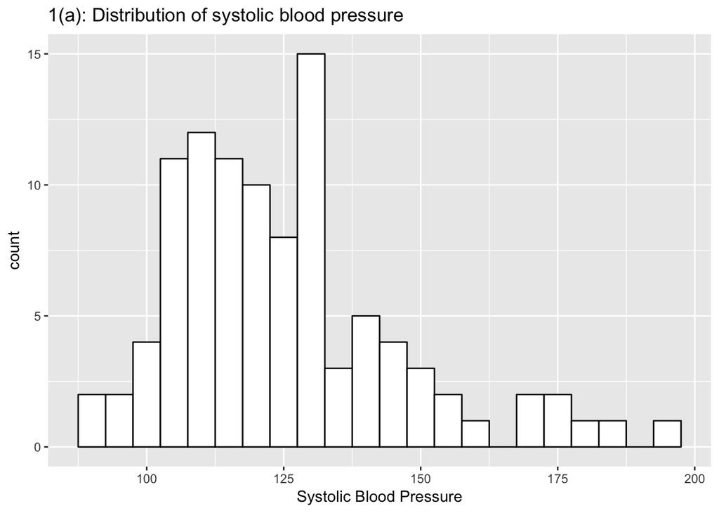

```r
ggplot(data,aes(x=sysBP))+geom_histogram(binwidth=5,color="black",fill="white")+
  xlab("Systolic Blood Pressure")+ggtitle("1(a): Distribution of systolic blood pressure")
```

Note the difference of labelling axes and making a main title in standard R and ggplot2.

A small trick here to separate code in .R file.

```r
########## part 1a ########
```

Forget the names of the variables? Try

```r
colnames(data)
```

```
## [1] "age"       "totalchol" "sysBP"     "weight"    "height"    "sedmins"
## [7] "obese"     "marriage"  "gender"
```

### b

It is slightly right skewed. There is a long right tail.

### c

(4.1.2 in R Handout - Summary Statistics and Plots)

A boxplot in standard R.

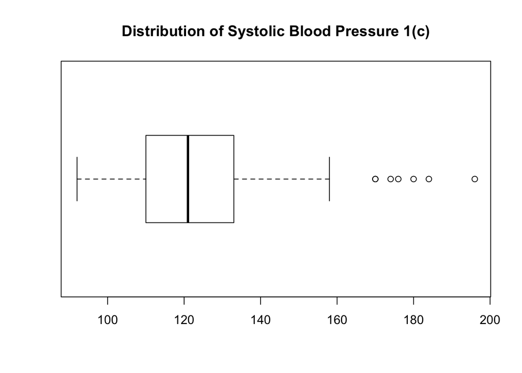

```r
boxplot(data$sysBP, horizontal = TRUE,main = "Distribution of Systolic Blood Pressure 1(c)")
```

A boxplot in ggplot2.

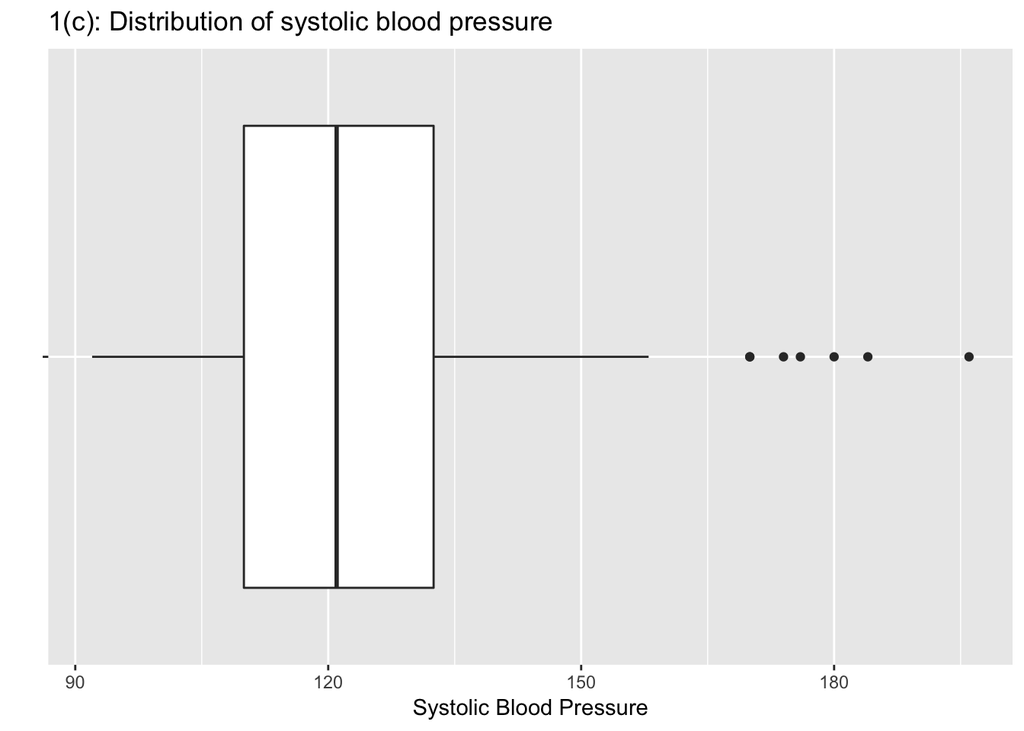

```r
ggplot(data, aes(y=sysBP, x = factor("")))+ geom_boxplot()+ylab("Systolic Blood Pressure")+
  xlab(" ")+coord_flip()+ggtitle("1(c): Distribution of systolic blood pressure")
```

Try without *coord_flip()* to see what this function does.

Use *?function_name* or *??function_name* to get information about a function. Note the difference between *?* and *??*.

### d

- There are six unusually large data points.
- Why there are no points on the left hand side?
- What do the lines mean in the boxplot?

## Problem 2

### a

(4.3.1 in R Handout - Summary Statistics and Plots)

Scatter plot in standard R.

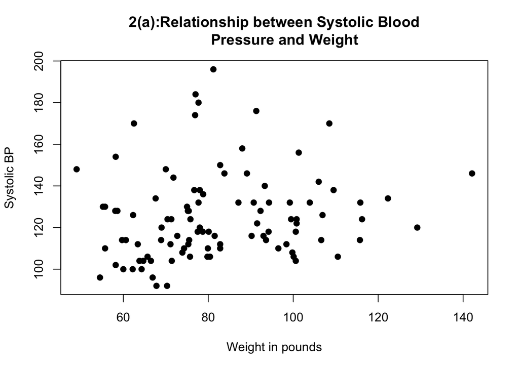

```r
plot(data$weight, data$sysBP, main = "2(a):Relationship between Systolic Blood
     Pressure and Weight",xlab = "Weight in pounds",ylab = "Systolic BP",pch = 19)
```

Scatter plot in ggplot2.

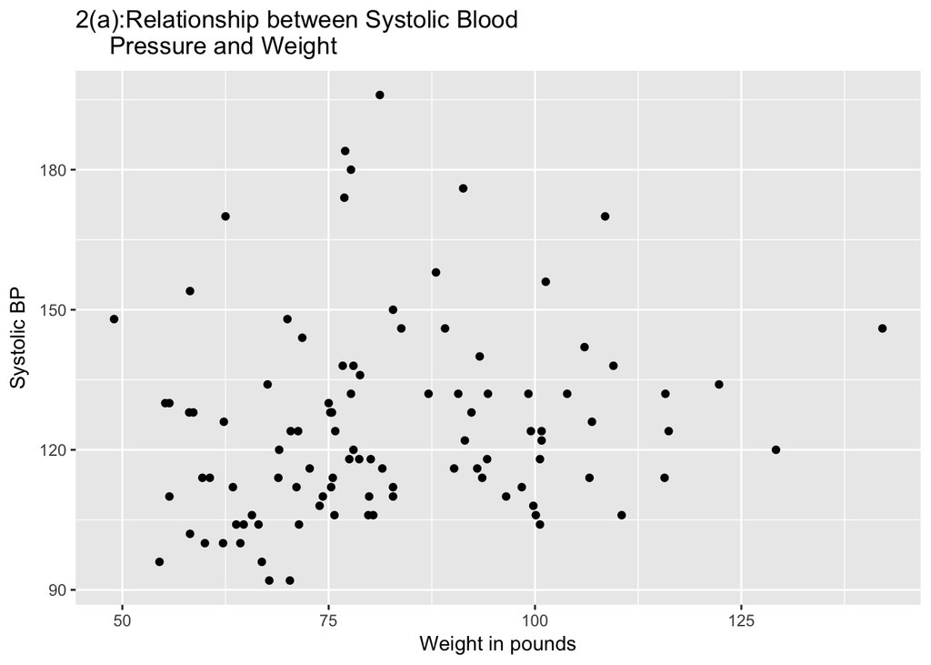

```r
qplot(weight, sysBP, data = data) + ggtitle("2(a):Relationship between Systolic Blood
     Pressure and Weight") + xlab("Weight in pounds") + ylab("Systolic BP")
```

Which variable appears on the x-axis and which appears on the y-axis?

### b

There seems a slight positive trend.

### c

(4.3.1 in R Handout - Summary Statistics and Plots)

Standard R.

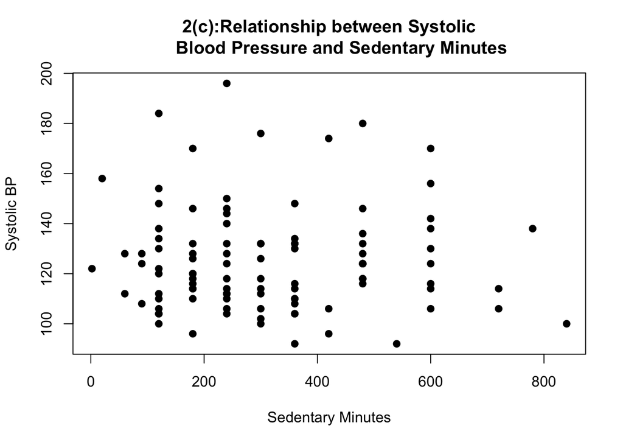

```r
plot(data$sedmins, data$sysBP, main = "2(c):Relationship between Systolic
     Blood Pressure and Sedentary Minutes",xlab = "Sedentary Minutes",ylab = "Systolic BP",pch = 19)
```

ggplot2.

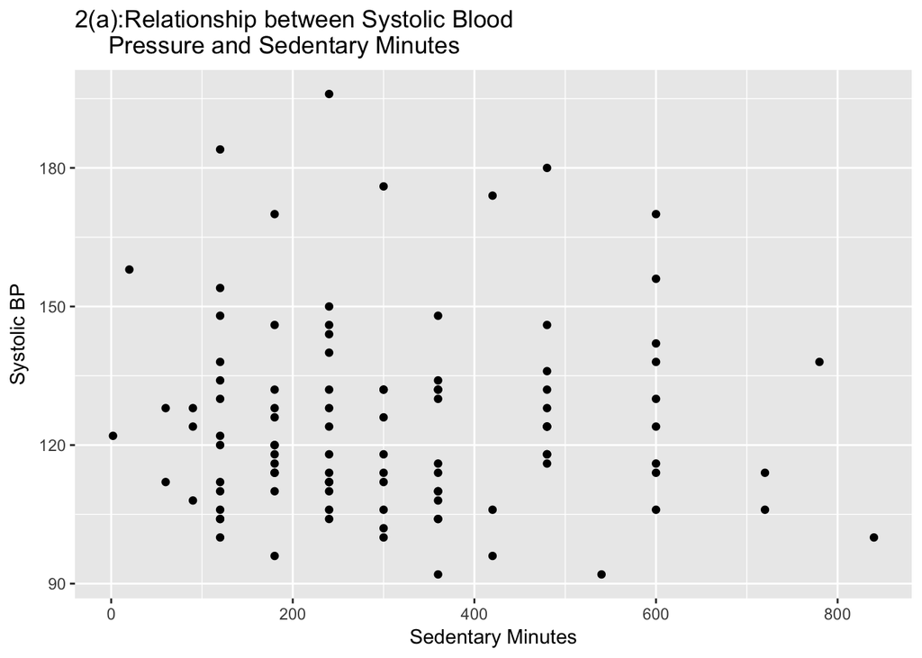

```r
qplot(sedmins, sysBP, data = data) + ggtitle("2(a):Relationship between Systolic Blood
     Pressure and Sedentary Minutes") + xlab("Sedentary Minutes") + ylab("Systolic BP")
```

### d

No obvious trend in the scatter plot.

## Problem 3

### a

(4.5 in R Handout - Summary Statistics and Plots)

Standard R.

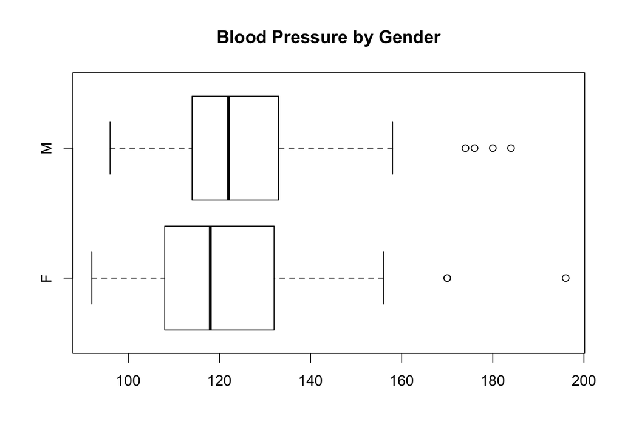

```r
boxplot(sysBP ~ gender, data = data, main = "Blood Pressure by Gender",horizontal = TRUE)
```

ggplot2.

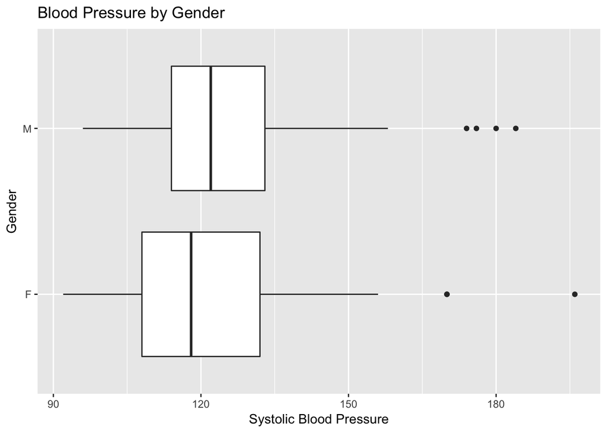

```r
ggplot(data,aes(y = sysBP,x =gender)) + geom_boxplot() + ylab("Systolic Blood Pressure") +
  xlab("Gender") + ggtitle("Blood Pressure by Gender") + coord_flip()
```

Compare with Problem 1c. Which part makes a groupd boxplot?

### b

There is no significant difference. Due to randomness, the boxplots will not overlap completely even if there is no difference between the two groups.

### c

(4.5.1 in R Handout - Summary Statistics and Plots)

ggplot2.

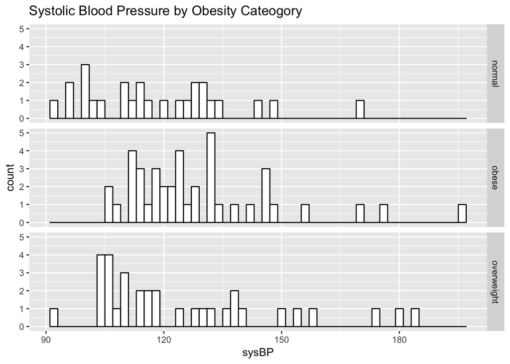

```r
ggplot(data, aes(x = sysBP)) + geom_histogram(binwidth = 2,color = "black",fill = "white")+
  facet_grid(obese~.)+ggtitle("Systolic Blood Pressure by Obesity Cateogory")
```

Compare with Problem 1a to see what makes the grouped histogram. Use *?* to look up *facet_grid()*. Try other different variables other than *obese* to see what we can get.

## Problem 4

### a

(1.1.1 in R Handout - Summary Statistics and Plots)

```r
round(mean(data$sysBP),4)
```

```
## [1] 125.12
```

What does *round()* do? Try *mean(data$sysBP)*.

What about *round(mean(data$sysBP),1)*?

### b

(2.1 in R Handout - Summary Statistics and Plots)

```r
aggregate(sysBP ~ marriage, data = data, mean)
```

```
##       marriage    sysBP
## 1     divorced 133.5000
## 2      married 124.7692
## 3 nevermarried 115.5000
## 4        other 126.0000
## 5      widowed 132.7500
```

### c

(2.2 in R Handout - Summary Statistics and Plots)

```r
aggregate(sysBP ~ marriage, data = data, sd)
```

```
##       marriage     sysBP
## 1     divorced 22.853287
## 2      married 21.343700
## 3 nevermarried 19.273471
## 4        other 22.205650
## 5      widowed  8.811518
```

Difference from last question?

### d

(2.3 in R Handout - Summary Statistics and Plots)

```r
aggregate(sysBP ~ marriage, data = data, sd)
```

[output not shown]

Difference from last two questions?

### e

(1.3 in R Handout - Summary Statistics and Plots)

```r
fivenum(data$weight)
```

```
## [1]  49.00  68.95  78.00  94.25 142.10
```

What is five number summary? Try to look up *fivenum()*.